# Session 2 - Intro to Tidyverse

This is a beginners tutorial for the R group of packages Tidyverse. It is a powerful collection of R packages designed for data science.

Load the tidyverse package.

```r
library("tidyverse")
```

## Importing the Data

N.B. you can get help on commands by typing a question mark followed by the command into the Console pane below, e.g. ?read_delim

```r
data_table <- read_delim("data/tidyverse_data_example.tsv", delim = "\t")
```

Now examine the imported table.

```r
head(data_table)
```

[output not shown]

## Tidying Imported Data

The gene names in the first column have additional numeric identifiers appended to the gene name, separated by an underscore. This would make it harder for searching for genes so it would be best to split the numbers from the gene names. Here we use the tidyr package separate_wider_delim() to split the gene name from then numeric value using the underscore delimiter (_)

```r
data_table <- data_table %>%
  separate_wider_delim(cols = Gene_names, delim = "_", names = c("Genes",NA))
data_table
```

| Genes | Sample1_1 | Sample1_2 | Sample1_3 | Sample1_4 | Sample1_5 | Sample2_1 | Sample2_2 | Sample2_3 | Sample2_4 | Sample2_5 | Sample3_1 | Sample3_2 | Sample3_3 | Sample3_4 | Sample3_5 | Sample4_1 | Sample4_2 | Sample4_3 | Sample4_4 | Sample4_5 | Sample5_1 | Sample5_2 | Sample5_3 | Sample5_4 | Sample5_5 |
| --- | --- | --- | --- | --- | --- | --- | --- | --- | --- | --- | --- | --- | --- | --- | --- | --- | --- | --- | --- | --- | --- | --- | --- | --- | --- |
| CHAC1 | 49 | 11 | 0 | 254 | 11 | 30 | 61 | 18 | 0 | 34 | 26 | 47 | 0 | 0 | 21 | 23 | 50 | 102 | 0 | 71 | 0 | 67 | 11 | 1 | 59 |
| GLRX | 2212 | 1884 | 845 | 1262 | 1193 | 1868 | 1895 | 1378 | 1515 | 1964 | 1959 | 1602 | 1629 | 741 | 1145 | 310 | 538 | 185 | 332 | 705 | 358 | 526 | 278 | 157 | 1746 |
| MEFV | 214 | 278 | 47 | 115 | 0 | 120 | 20 | 23 | 824 | 52 | 121 | 150 | 129 | 20 | 66 | 26 | 55 | 98 | 53 | 100 | 10 | 20 | 31 | 66 | 80 |
| STXBP1 | 361 | 283 | 196 | 362 | 163 | 221 | 333 | 183 | 109 | 203 | 131 | 150 | 187 | 149 | 352 | 100 | 122 | 129 | 150 | 163 | 0 | 233 | 26 | 83 | 69 |
| AKAP8L | 203 | 34 | 86 | 101 | 0 | 149 | 56 | 254 | 168 | 41 | 83 | 61 | 174 | 62 | 42 | 88 | 107 | 66 | 113 | 209 | 103 | 49 | 168 | 100 | 114 |
| AKR1C1 | 18 | 22 | 0 | 279 | 235 | 0 | 51 | 0 | 54 | 0 | 145 | 66 | 52 | 3 | 52 | 14 | 54 | 0 | 83 | 0 | 85 | 0 | 22 | 27 | 18 |
| CTSL | 2044 | 1811 | 839 | 1891 | 2021 | 2795 | 1261 | 1176 | 10090 | 1759 | 1281 | 2500 | 1396 | 889 | 1760 | 833 | 550 | 978 | 616 | 1824 | 884 | 607 | 1160 | 723 | 1556 |
| IGFBP4 | 1197 | 775 | 671 | 1192 | 1567 | 1397 | 530 | 566 | 1028 | 587 | 563 | 1039 | 960 | 312 | 547 | 824 | 1075 | 1146 | 662 | 1090 | 446 | 1251 | 322 | 1175 | 96 |
| RAP1GAP | 18 | 1 | 0 | 0 | 0 | 0 | 27 | 0 | 0 | 12 | 0 | 0 | 0 | 4 | 0 | 26 | 0 | 0 | 0 | 46 | 0 | 16 | 28 | 0 | 1 |
| COQ8A | 70 | 20 | 79 | 43 | 78 | 36 | 122 | 133 | 1 | 115 | 129 | 83 | 43 | 87 | 0 | 22 | 0 | 0 | 17 | 0 | 0 | 38 | 73 | 0 | 43 |

[output cut: 990 more lines]

Now the data needs to be “tidied” for plotting with ggplot2. We need to transpose the expression data columns into one column of expression values, called “Expression” and create a column, called “Sample”, with the sample names for the expression values. Using the tidyr command pivot_longer(). We need to specify which columns to use, this can be done using the cols parameter either explicitly naming all the columns to be included or state which columns to ignore during to transposition. Either method is fine but it is preferable to use the shortest list to keep the code readable, in my opinion. So in this example, we omit the Genes column from the transposition by calling cols = -Genes, a minus sign and the column name.

```r
pivot_data_table <- data_table %>%
  pivot_longer(-Genes, names_to = "Sample", values_to = "Expression")

pivot_data_table
```

| Genes | Sample | Expression |
| --- | --- | --- |
| CHAC1 | Sample1_1 | 49 |
| CHAC1 | Sample1_2 | 11 |
| CHAC1 | Sample1_3 | 0 |
| CHAC1 | Sample1_4 | 254 |
| CHAC1 | Sample1_5 | 11 |
| CHAC1 | Sample2_1 | 30 |
| CHAC1 | Sample2_2 | 61 |
| CHAC1 | Sample2_3 | 18 |
| CHAC1 | Sample2_4 | 0 |
| CHAC1 | Sample2_5 | 34 |

[output cut: 990 more lines]

In these data the samples names include the replicates which we would like to separate out into “Samples” and “Replicates” columns. Using the example for the gene names above create the Samples and Replicates.

```r
pivot_data_table_replicates <- pivot_data_table %>%
  separate_wider_delim(Sample, delim = "_", names = c("Samples","Replicates"))
pivot_data_table_replicates
```

| Genes | Samples | Replicates | Expression |
| --- | --- | --- | --- |
| CHAC1 | Sample1 | 1 | 49 |
| CHAC1 | Sample1 | 2 | 11 |
| CHAC1 | Sample1 | 3 | 0 |
| CHAC1 | Sample1 | 4 | 254 |
| CHAC1 | Sample1 | 5 | 11 |
| CHAC1 | Sample2 | 1 | 30 |
| CHAC1 | Sample2 | 2 | 61 |
| CHAC1 | Sample2 | 3 | 18 |
| CHAC1 | Sample2 | 4 | 0 |
| CHAC1 | Sample2 | 5 | 34 |

[output cut: 990 more lines]

Our data table is now in good shape for plotting.

## Dates

Although not in these data, it is possible you could have dates in your data table. R has a data type for date and time. Tidyverse has a package, lubridate, that helps re-format table entries in the correct format.

```r
as.numeric(date_example)
```

```
[1] NA
```

```r
ludbridate_date_example <- ymd(date_example)
ludbridate_date_example
```

```
[1] "2023-05-24"
```

```r
class(ludbridate_date_example)
```

```
[1] "Date"
```

Try with the following formats:- 20230523 23/5/2023 5|23-23

## Plotting

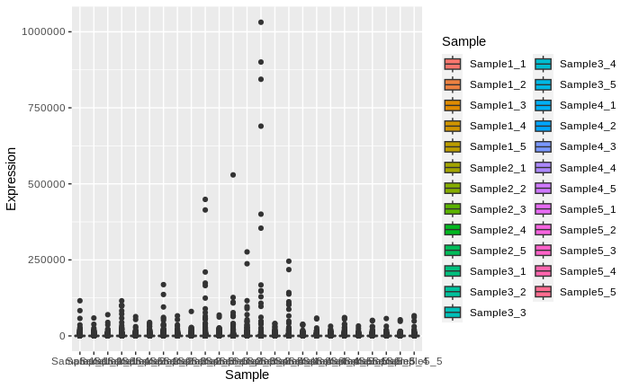

```r
ggplot(pivot_data_table, aes(x = Sample, y = Expression, fill = Sample)) +
  geom_boxplot()
```

Transcriptomics data consists of a large number of genes with very low or no expression so most of the data is near the bottom of the y axis. The graph would be more informative if the expression values were log transformed, add the ggplot2 function scale_y_log10()

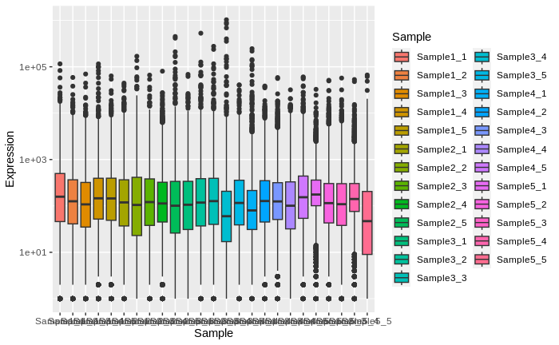

```r
ggplot(pivot_data_table, aes(x = Sample, y = Expression, fill = Sample)) +
  geom_boxplot() +
  scale_y_log10()
```

Now that the boxplot looks more informative, label the axes. The y axis should indicate that it is log transformed and the x axis label is redundant as the samples are called Sample**. Use the ggplot2 function labs.

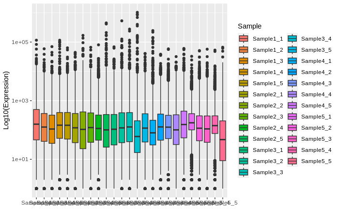

```r
ggplot(pivot_data_table, aes(x = Sample, y = Expression, fill = Sample)) +
  geom_boxplot() +
  scale_y_log10() +
  labs(x = NULL,
       y = "Log10(Expression)")
```

Now add nicer colours, scale_fill_viridis_d()

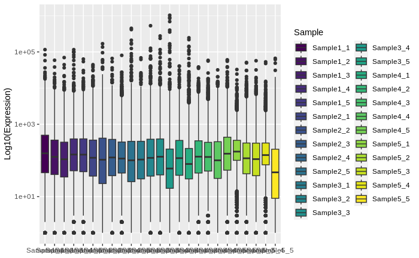

```r
ggplot(pivot_data_table, aes(x = Sample, y = Expression, fill = Sample)) +
  geom_boxplot() +
  scale_y_log10() +
  labs(x = NULL,
       y = "Log10(Expression)") +
  scale_fill_viridis_d()
```

Change the look of the plot using one of the following built in themes: theme_default() theme_bw() theme_linedraw() theme_light() theme_dark() theme_minimal() theme_classic() theme_void()

Try a few and choose the one you prefer.

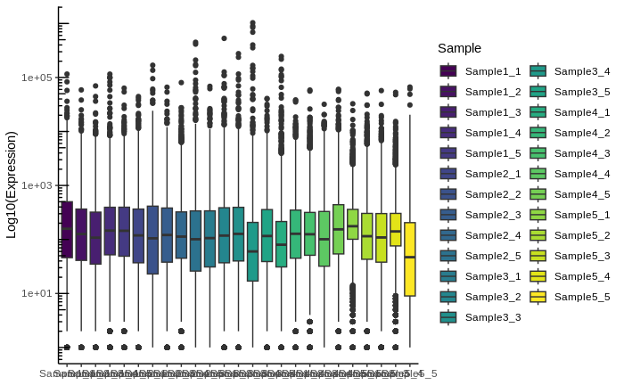

```r
ggplot(pivot_data_table, aes(x = Sample, y = Expression, fill = Sample)) +
  geom_boxplot() +
  scale_y_log10() +
  labs(x = NULL,
       y = "Log10(Expression)") +
  scale_fill_viridis_d() +
  annotation_logticks(sides = "l") +
 theme_classic()
```

The theme you have chosen can be modified by adding the theme() command. For example the labels on the x axis are currently overlapping each other so we could rotate them 90˚ to make them readable, something like this theme(axis.text.x = element_text(angle = 90, vjust = 0.5, hjust=1)). This command changes the angle of the x axis labels then adjusts the vertical and horizontal label position.

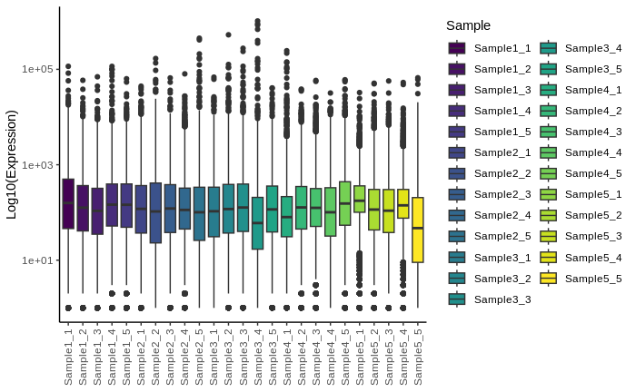

```r
ggplot(pivot_data_table, aes(x = Sample, y = Expression, fill = Sample)) +
  geom_boxplot() +
  scale_y_log10() +
  labs(x = NULL,
       y = "Log10(Expression)") +
  scale_fill_viridis_d() +
 theme_classic() +
  theme(axis.text.x = element_text(angle = 90, vjust = 0.5, hjust=1))
```

The plot legend is not required, this can also be controlled by modifying the theme, in a comma separated list. Add the command legend.position, which can be set to “left”, “right,”top”, “bottom” or “none”.

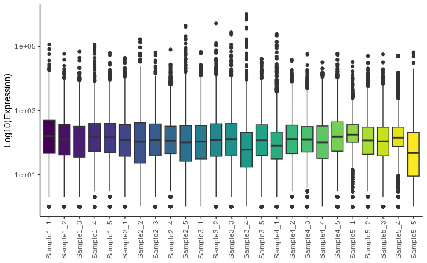

```r
ggplot(pivot_data_table, aes(x = Sample, y = Expression, fill = Sample)) +
  geom_boxplot() +
  scale_y_log10() +
  labs(x = NULL,
       y = "Log10(Expression)") +
  scale_fill_viridis_d() +
 theme_classic() +
  theme(axis.text.x = element_text(angle = 90, vjust = 0.5, hjust=1),
        legend.position = "none")
```

## Subsetting Data

```r
gene_of_interest <- pivot_data_table %>%
  filter(Genes == "SIX1")

head(gene_of_interest)
```

| Genes | Sample | Expression |
| --- | --- | --- |
| SIX1 | Sample1_1 | 0 |
| SIX1 | Sample1_2 | 21 |
| SIX1 | Sample1_3 | 0 |
| SIX1 | Sample1_4 | 0 |
| SIX1 | Sample1_5 | 0 |
| SIX1 | Sample2_1 | 0 |

[figure not shown]

Can filet the dataframe for a set of genes in a vector, I will look for a family of sine oculus like homeobox genes, SIX1, SIX2, SIX3, SIX4 & SIX5

[output not shown]

[output cut: 140 more lines]

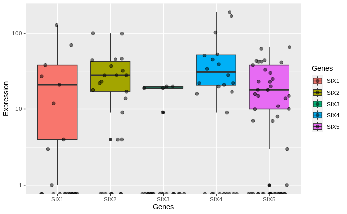

```r
ggplot(genes_of_interest, aes(x = Genes, y = Expression, fill = Genes)) +
  geom_boxplot() +
  geom_jitter(size = 2, alpha = 0.5) +
  scale_y_log10()
```